# Copy_of_Untitled2-3

Collaborator

Github Site Link: https://teothemayo.github.io/DataScienceLondon-Teo/

**Background: **

At the intersection of environmental science, data analysis, and global health, our project explores the relationships between rising sea levels, global average temperatures, and carbon emissions across different years. Our project investigates and leverages data to address pressing environmental challenges and aims to uncover insights that could help deduce future temperatures so that the world can be more prepared. Through examining these interconnected factors, we want to discover the complex interplay between the actions of people and environmental responses over time. This analysis will focus on identifying correlations between global average temperatures and sea level rise, as well as exploring the potential predictive power of historical temperature, sea level, and carbon emission data for forecasting future climate scenarios. This project not only combines elements from environmental science, statistics, and data analysis but also highlights the importance of interdisciplinary approaches in addressing global challenges. By diving deep into this data, we hope to contribute valuable insights that can inform climate action and policymaking, ultimately working towards a more sustainable future.

**Data Source: **

Our project leverages three key datasets sourced two from Kaggle and one from the Our World in Data, to analyze the relationships between global average temperatures, rising sea levels, and carbon emissions over time. The first dataset, “Mean Temperature for Countries by Year” provides annual temperature data for various countries, enabling a detailed exploration of recent global warming trends. The second dataset, “Global Sea Level (1993-2021),” offers nearly three decades of sea level measurements, critical for evaluating the correlation between temperature increases and sea level rise. Additionally, we incorporate CO₂ emissions data to examine how humans influence these environmental changes. These datasets were accessed using the kagglehub library and processed with Python and pandas for efficient analysis.

While these datasets provide valuable insights into climate change dynamics, they have some limitations. For instance, the sea level dataset covers a relatively short time frame (1993-2021), which may limit long-term trend analysis. Despite this, combining these datasets allows us to explore significant correlations and patterns that can inform predictive models and climate change mitigation strategies.

```python
import kagglehub

path = kagglehub.dataset_download("palinatx/mean-temperature-for-countries-by-year-2014-2022")
path1 = kagglehub.dataset_download("kkhandekar/global-sea-level-1993-2021")
print(path)

!cd /root/.cache/kagglehub/datasets/berkeleyearth/climate-change-earth-surface-temperature-data/versions/2
!ls /root/.cache/kagglehub/datasets/palinatx/mean-temperature-for-countries-by-year-2014-2022/versions/3/combined_temperature.csv
```

```
Downloading from https://www.kaggle.com/api/v1/datasets/download/palinatx/mean-temperature-for-countries-by-year-2014-2022?dataset_version_number=3...
```

```
Extracting files...
```

```
Downloading from https://www.kaggle.com/api/v1/datasets/download/kkhandekar/global-sea-level-1993-2021?dataset_version_number=2...
```

```
Extracting files...
/root/.cache/kagglehub/datasets/palinatx/mean-temperature-for-countries-by-year-2014-2022/versions/3
/bin/bash: line 1: cd: /root/.cache/kagglehub/datasets/berkeleyearth/climate-change-earth-surface-temperature-data/versions/2: No such file or directory
```

```
/root/.cache/kagglehub/datasets/palinatx/mean-temperature-for-countries-by-year-2014-2022/versions/3/combined_temperature.csv
```

**E.T.L (Extraction, Transformation, Loading) **

The ETL process for our project encompasses several steps to analyze the relationships between global average temperatures, rising sea levels, and carbon emissions. Initially, we extract the datasets from Kaggle and using the kagglehub library. The extraction is initiated with code that retrieves these datasets and confirms their successful download. Following extraction, we move to the transformation phase. In this step, we load the data into pandas DataFrames and perform various operations to clean and prepare the data for analysis. This includes filtering for specific countries, and aggregating data to calculate global averages. Finally, in the loading phase, we visualize the transformed data using libraries like seaborn and matplotlib.

Upon executing this code, the datasets are downloaded and extracted from their respective sources. The following code extracts and analyzes temperature data for Italy from a larger global dataset. It imports libraries like pandas, numpy, seaborn, and matplotlib for data manipulation and visualization. The data is loaded into a pandas DataFrame named countryTemp using pd.read_csv(). It then calculates global average temperatures by grouping the data by year.

|  | Country | Year | Annual Mean | 5-yr smooth | Code |
| --- | --- | --- | --- | --- | --- |
| 0 | Dominican Republic | 1901 | 23.71 | 23.65 | DOM |
| 1 | Dominican Republic | 1902 | 23.40 | 23.52 | DOM |
| 2 | Dominican Republic | 1903 | 23.45 | 23.38 | DOM |
| 3 | Dominican Republic | 1904 | 23.03 | 23.26 | DOM |
| 4 | Dominican Republic | 1905 | 23.44 | 23.16 | DOM |
| ... | ... | ... | ... | ... | ... |
| 105 | Dominican Republic | 2006 | 24.57 | 24.37 | DOM |
| 106 | Dominican Republic | 2007 | 24.33 | 24.31 | DOM |
| 107 | Dominican Republic | 2008 | 23.95 | 24.26 | DOM |
| 108 | Dominican Republic | 2009 | 24.31 | 24.24 | DOM |
| 109 | Dominican Republic | 2010 | 24.32 | 24.23 | DOM |

110 rows × 5 columns

|  | Year | Annual Mean | 5-yr smooth |
| --- | --- | --- | --- |
| 0 | 1901 | 18.705471 | 18.665824 |
| 1 | 1902 | 18.531000 | 18.614176 |
| 2 | 1903 | 18.580118 | 18.565118 |
| 3 | 1904 | 18.487647 | 18.523824 |
| 4 | 1905 | 18.555000 | 18.493471 |
| 5 | 1906 | 18.639294 | 18.477294 |
| 6 | 1907 | 18.343176 | 18.478647 |
| 7 | 1908 | 18.465000 | 18.493941 |
| 8 | 1909 | 18.518529 | 18.519118 |
| 9 | 1910 | 18.551588 | 18.547059 |

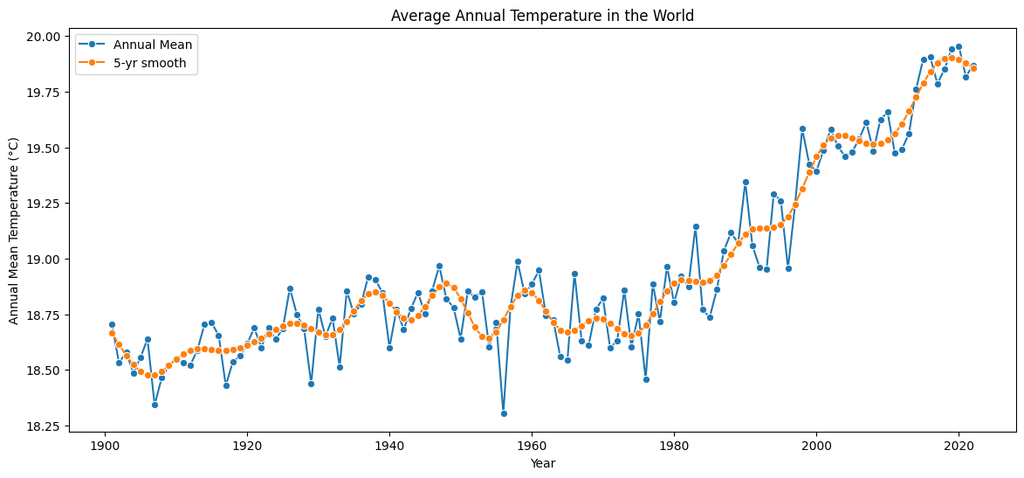

|  | Country | Year | Annual Mean | 5-yr smooth | Code |
| --- | --- | --- | --- | --- | --- |
| 19642 | Italy | 1901 | 11.53 | 11.78 | ITA |
| 19643 | Italy | 1902 | 11.77 | 11.77 | ITA |
| 19644 | Italy | 1903 | 11.83 | 11.75 | ITA |
| 19645 | Italy | 1904 | 12.28 | 11.74 | ITA |
| 19646 | Italy | 1905 | 11.67 | 11.73 | ITA |
| 19647 | Italy | 1906 | 11.68 | 11.73 | ITA |
| 19648 | Italy | 1907 | 11.71 | 11.73 | ITA |
| 19649 | Italy | 1908 | 11.47 | 11.74 | ITA |
| 19650 | Italy | 1909 | 11.40 | 11.76 | ITA |
| 19651 | Italy | 1910 | 11.76 | 11.77 | ITA |

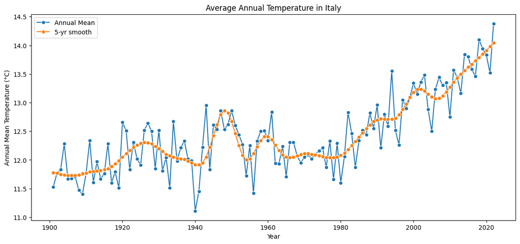

```python
import pandas as pd
import numpy as np
import seaborn as sns
import matplotlib.pyplot  as plt

countryTemp = pd.read_csv('/root/.cache/kagglehub/datasets/palinatx/mean-temperature-for-countries-by-year-2014-2022/versions/3/combined_temperature.csv')
countryTemp = pd.DataFrame(countryTemp)
display(countryTemp.head(110))

#Average World Temperature
worldDF = countryTemp.groupby('Year').agg({'Annual Mean': 'mean', '5-yr smooth': 'mean'}).reset_index()
display(worldDF.head(10))
plt.figure(figsize=(14, 6))
sns.lineplot(data=worldDF, x='Year', y='Annual Mean', marker='o', label='Annual Mean')
sns.lineplot(data=worldDF, x='Year', y='5-yr smooth', marker='o', label='5-yr smooth')
plt.title(f'Average Annual Temperature in the World')
plt.ylabel('Annual Mean Temperature (°C)')
plt.xlabel('Year')
plt.legend()
plt.show()


#Italy Temperature
italyDF = countryTemp[countryTemp['Country'] == 'Italy']
display(italyDF.head(10))
plt.figure(figsize=(14, 6))
sns.lineplot(data=italyDF, x='Year', y='Annual Mean', marker='o', label='Annual Mean')
sns.lineplot(data=italyDF, x='Year', y='5-yr smooth', marker='o', label='5-yr smooth')
plt.title(f'Average Annual Temperature in Italy')
plt.ylabel('Annual Mean Temperature (°C)')
plt.xlabel('Year')
plt.legend()
plt.show()
```

**CO2 Emissions: **

The code below loads CO2 emission data from a CSV file, processes it to extract information for Italy and global averages, and creates visualizations of CO2 emission trends over time. The code imports the CO2 emission data from a CSV file into a pandas DataFrame. Next, we filter the data to focus on Italy's CO2 emissions from 1901 onwards for display purposes. A line plot is created to visualize Italy's annual CO2 emissions over time. Similarly, for global CO2 emissions, the code aggregates the data by year to calculate mean emissions worldwide.

|  | Entity | Code | Year | Annual CO₂ emissions |
| --- | --- | --- | --- | --- |
| 0 | Afghanistan | AFG | 1949 | 14656.0 |
| 1 | Afghanistan | AFG | 1950 | 84272.0 |
| 2 | Afghanistan | AFG | 1951 | 91600.0 |
| 3 | Afghanistan | AFG | 1952 | 91600.0 |
| 4 | Afghanistan | AFG | 1953 | 106256.0 |
| 5 | Afghanistan | AFG | 1954 | 106256.0 |
| 6 | Afghanistan | AFG | 1955 | 153888.0 |
| 7 | Afghanistan | AFG | 1956 | 183200.0 |
| 8 | Afghanistan | AFG | 1957 | 293120.0 |
| 9 | Afghanistan | AFG | 1958 | 329760.0 |

```
Index(['Entity', 'Code', 'Year', 'Annual CO₂ emissions'], dtype='object')
```

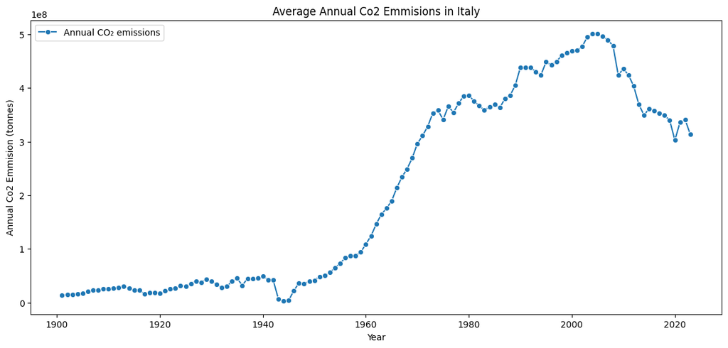

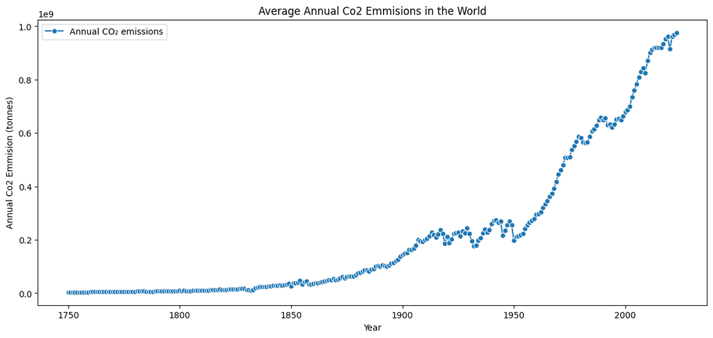

```python
import os

co2emmision = pd.read_csv('annual-co2-emissions-per-country.csv')
co2emmision = pd.DataFrame(co2emmision)
display(co2emmision.head(10))

display(co2emmision.columns)

#Get data for italy, make sure years mach up
italyco2 = co2emmision[co2emmision['Entity'] == 'Italy']
italyco2 = italyco2[italyco2['Year'] >= 1901]
italyco2
#Italy co2Emmisions
plt.figure(figsize=(14, 6))
sns.lineplot(data=italyco2, x='Year', y='Annual CO₂ emissions', marker='o', label='Annual CO₂ emissions')
plt.title(f'Average Annual Co2 Emmisions in Italy')
plt.ylabel('Annual Co2 Emmision (tonnes)')
plt.xlabel('Year')
plt.legend()
plt.show()


#Get data for world, make sure years mach up
worldco2 = co2emmision.groupby('Year').agg({'Annual CO₂ emissions': 'mean'}).reset_index()
#World co2Emmisions
plt.figure(figsize=(14, 6))
sns.lineplot(data=worldco2, x='Year', y='Annual CO₂ emissions', marker='o', label='Annual CO₂ emissions')
plt.title(f'Average Annual Co2 Emmisions in the World')
plt.ylabel('Annual Co2 Emmision (tonnes)')
plt.xlabel('Year')
plt.legend()
plt.show()
```

Another line plot is generated to display the global annual CO2 emission trends. Both visualizations use seaborn's lineplot function.

Data merging, normalization, and visualization for both Italy and global CO₂ emissions and temperature data are all illustrated in the code below. First, our model merges Italy's temperature data (italyDF) with its CO₂ emissions data (italyco2) to create a combined DataFrame called italyMerged. The data is then normalized using the z-score method for both annual mean temperatures and CO₂ emissions, allowing for better comparison of trends. we need to standerdize because teemperature and CO₂ emissions have different units and scales.

|  | Country | Year | Annual Mean | 5-yr smooth | Code | Entity | Annual CO₂ emissions |
| --- | --- | --- | --- | --- | --- | --- | --- |
| 0 | Italy | 1901 | 11.53 | 11.78 | ITA | Italy | 13520160.0 |
| 1 | Italy | 1902 | 11.77 | 11.77 | ITA | Italy | 15015072.0 |
| 2 | Italy | 1903 | 11.83 | 11.75 | ITA | Italy | 15315520.0 |
| 3 | Italy | 1904 | 12.28 | 11.74 | ITA | Italy | 16187551.0 |
| 4 | Italy | 1905 | 11.67 | 11.73 | ITA | Italy | 17843680.0 |
| 5 | Italy | 1906 | 11.68 | 11.73 | ITA | Italy | 21089984.0 |
| 6 | Italy | 1907 | 11.71 | 11.73 | ITA | Italy | 22808400.0 |
| 7 | Italy | 1908 | 11.47 | 11.74 | ITA | Italy | 23262736.0 |
| 8 | Italy | 1909 | 11.40 | 11.76 | ITA | Italy | 25702960.0 |
| 9 | Italy | 1910 | 11.76 | 11.77 | ITA | Italy | 25735936.0 |

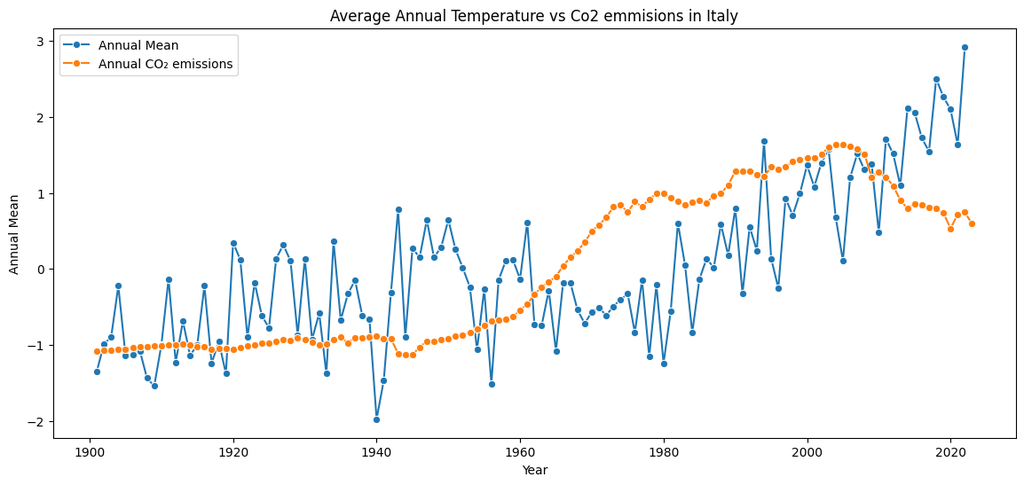

|  | Year | Annual Mean | 5-yr smooth | Annual CO₂ emissions |
| --- | --- | --- | --- | --- |
| 0 | 1901 | 18.705471 | 18.665824 | 1.489848e+08 |
| 1 | 1902 | 18.531000 | 18.614176 | 1.521439e+08 |
| 2 | 1903 | 18.580118 | 18.565118 | 1.630048e+08 |
| 3 | 1904 | 18.487647 | 18.523824 | 1.634754e+08 |
| 4 | 1905 | 18.555000 | 18.493471 | 1.681852e+08 |
| 5 | 1906 | 18.639294 | 18.477294 | 1.787954e+08 |
| 6 | 1907 | 18.343176 | 18.478647 | 2.009740e+08 |
| 7 | 1908 | 18.465000 | 18.493941 | 1.947404e+08 |
| 8 | 1909 | 18.518529 | 18.519118 | 1.939645e+08 |
| 9 | 1910 | 18.551588 | 18.547059 | 2.005713e+08 |

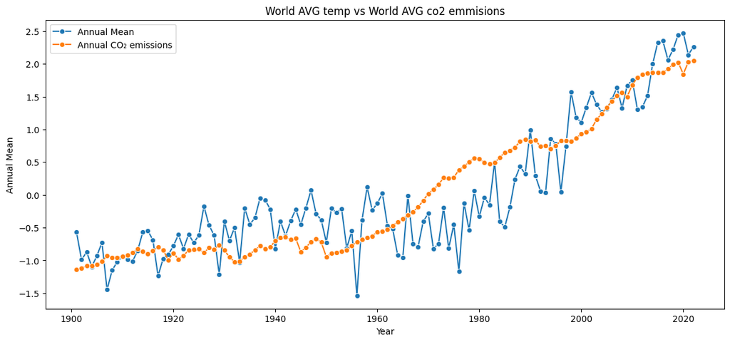

```python
#ITALY DATA
#Create merged table
italyMerged = italyDF.merge(italyco2, how='outer')
display(italyMerged.head(10))

#Normalize data (z-score)
italyMerged['Annual Mean'] = (italyMerged['Annual Mean'] - italyMerged['Annual Mean'].mean()) / italyMerged['Annual Mean'].std()
italyMerged['Annual CO₂ emissions'] = (italyMerged['Annual CO₂ emissions'] - italyMerged['Annual CO₂ emissions'].mean()) / italyMerged['Annual CO₂ emissions'].std()

#plotting of graph
plt.figure(figsize=(14, 6))
sns.lineplot(data=italyMerged, x='Year', y='Annual Mean', marker='o', label='Annual Mean')
sns.lineplot(data=italyMerged, x='Year', y='Annual CO₂ emissions', marker='o', label='Annual CO₂ emissions')
plt.title(f'Average Annual Temperature vs Co2 emmisions in Italy')
plt.ylabel('Annual Mean')
plt.xlabel('Year')
plt.legend()
plt.show()



#WORLD DATA
#Create world merged table
worldMerged = worldDF.merge(worldco2, on='Year')
display(worldMerged.head(10))

#Normalize data (z-score)
worldMerged['Annual Mean'] = (worldMerged['Annual Mean'] - worldMerged['Annual Mean'].mean()) / worldMerged['Annual Mean'].std()
worldMerged['Annual CO₂ emissions'] = (worldMerged['Annual CO₂ emissions'] - worldMerged['Annual CO₂ emissions'].mean()) / worldMerged['Annual CO₂ emissions'].std()

#plotting of graph
plt.figure(figsize=(14, 6))
sns.lineplot(data=worldMerged, x='Year', y='Annual Mean', marker='o', label='Annual Mean')
sns.lineplot(data=worldMerged, x='Year', y='Annual CO₂ emissions', marker='o', label='Annual CO₂ emissions')
plt.title(f'World AVG temp vs World AVG co2 emmisions')
plt.ylabel('Annual Mean')
plt.xlabel('Year')
plt.legend()

plt.show()
```

The line plot above visualizes the annual mean temperature and CO₂ emissions for Italy over time. Similarly, we also merge the global temperature data (worldDF) with global CO₂ emissions data (worldco2) to create worldMerged. After standerdizing, the line plot is then created to compare global average temperatures against global CO₂ emissions. This data will be later used in our model to predict global world temperatures.

**Predicting Annual Mean Temperature Using Linear Regression: **

Here we implement a linear regression model to analyze and predict annual mean temperatures based on historical 5 year smooth temperature and CO₂ emissions data. After loading the preproccessed and merged dataset, the code separates this data into two subsets: one for years before and including 2020, and another for years after 2020. This is done with the intention to use year 2021 data to test our model.

The exploratory data analysis (EDA) section visualizes trends in annual mean temperatures and CO₂ emissions over the years using line plots. A correlation matrix is computed to examine relationships between variables, which is visualized in a heatmap. Next, the code defines the features (5-year smoothed temperature and annual CO₂ emissions) and the target variable (annual mean temperature). It splits the data into training and testing sets. A linear regression model is then importent along with the standard scaler and mean squared error from the sklearn module. the testing sets are trained on the training data. To predict the annual mean temperature for 2021, a new input value is created based on known smoothed temperature and CO₂ emissions for that year. The model's prediction is displayed alongside its performance evaluation using mean squared error (MSE) on the test set.

|  | Year | Annual Mean | 5-yr smooth | Annual CO₂ emissions |
| --- | --- | --- | --- | --- |
| 120 | 2021 | 19.818059 | 19.877353 | 9.621958e+08 |
| 121 | 2022 | 19.868235 | 19.856471 | 9.674599e+08 |

|  | Year | Annual Mean | 5-yr smooth | Annual CO₂ emissions |
| --- | --- | --- | --- | --- |
| 0 | 1901 | 18.705471 | 18.665824 | 1.489848e+08 |
| 1 | 1902 | 18.531000 | 18.614176 | 1.521439e+08 |
| 2 | 1903 | 18.580118 | 18.565118 | 1.630048e+08 |
| 3 | 1904 | 18.487647 | 18.523824 | 1.634754e+08 |
| 4 | 1905 | 18.555000 | 18.493471 | 1.681852e+08 |
| 5 | 1906 | 18.639294 | 18.477294 | 1.787954e+08 |
| 6 | 1907 | 18.343176 | 18.478647 | 2.009740e+08 |
| 7 | 1908 | 18.465000 | 18.493941 | 1.947404e+08 |
| 8 | 1909 | 18.518529 | 18.519118 | 1.939645e+08 |
| 9 | 1910 | 18.551588 | 18.547059 | 2.005713e+08 |

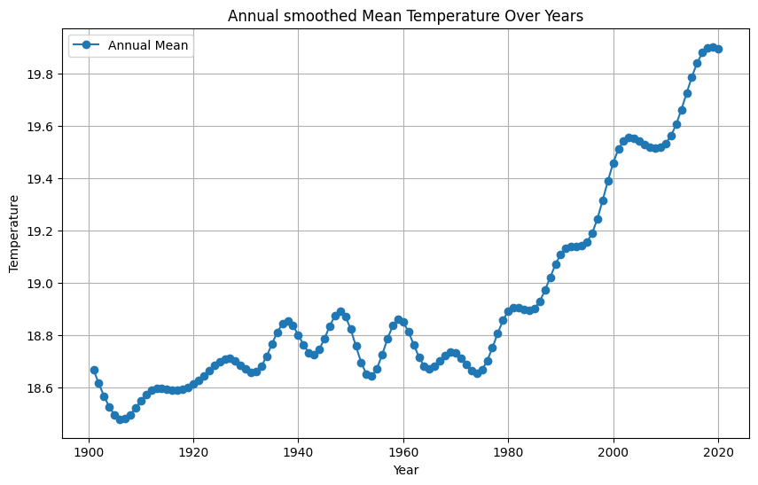

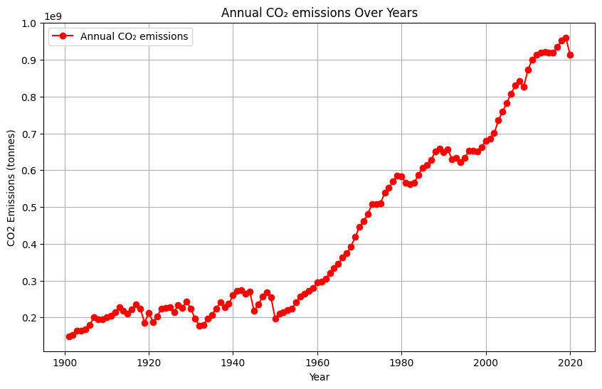

```
Correlation matrix:
                          Year  Annual Mean  5-yr smooth  Annual CO₂ emissions
Year                  1.000000     0.821830     0.857502              0.938677
Annual Mean           0.821830     1.000000     0.958865              0.867414
5-yr smooth           0.857502     0.958865     1.000000              0.907410
Annual CO₂ emissions  0.938677     0.867414     0.907410              1.000000
```

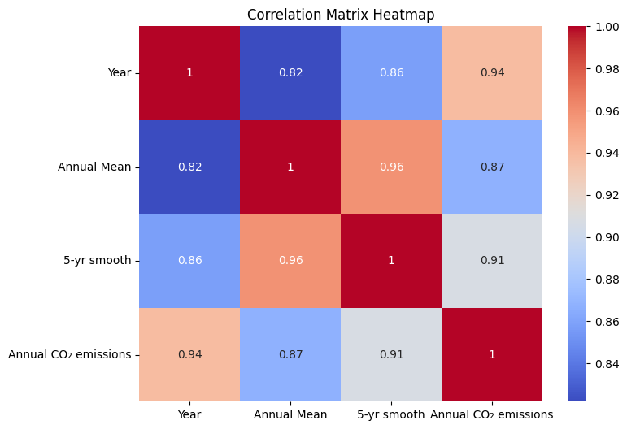

```
Predicted Annual Mean Temperature for 2021: 19.878867244793064

Mean Squared Error on test set: 0.017307374926318272
```

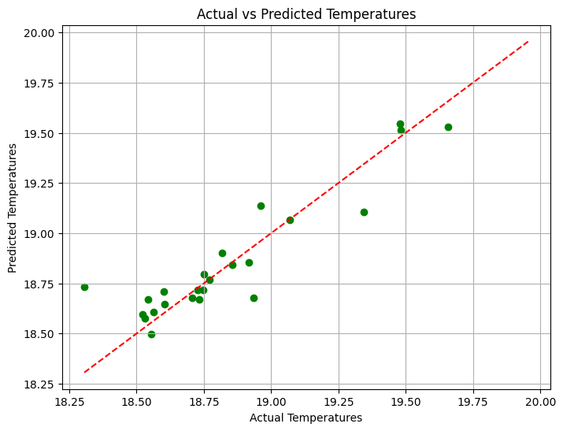

```python
from sklearn.model_selection import train_test_split
from sklearn.linear_model import LinearRegression
from sklearn.preprocessing import StandardScaler
from sklearn.metrics import mean_squared_error
import numpy as np

#Load and Preprocess Data
moredata = worldMerged[worldMerged['Year'] > 2020].copy()
data = worldMerged[worldMerged['Year'] <= 2020].copy()

display(moredata.head(10))
display(worldMerged.head(10))

#EDA, plot Annual Mean Temperature over Years
plt.figure(figsize=(10,6))
plt.plot(data['Year'], data['5-yr smooth'], marker='o', label='Annual Mean')
plt.xlabel('Year')
plt.ylabel('Temperature')
plt.title('Annual smoothed Mean Temperature Over Years')
plt.legend()
plt.grid(True)
plt.show()

#Plot Annual CO2 emissions over years
plt.figure(figsize=(10,6))
plt.plot(data['Year'], data['Annual CO₂ emissions'], marker='o', color='red', label='Annual CO₂ emissions')
plt.xlabel('Year')
plt.ylabel('CO2 Emissions (tonnes)')
plt.title('Annual CO₂ emissions Over Years')
plt.legend()
plt.grid(True)
plt.show()

#correlations
corr_matrix = data.corr()
print("\nCorrelation matrix:")
print(corr_matrix)

plt.figure(figsize=(8,6))
sns.heatmap(corr_matrix, annot=True, cmap='coolwarm')
plt.title('Correlation Matrix Heatmap')
plt.show()

# Define features and target
X = data[['5-yr smooth', 'Annual CO₂ emissions']]
y = data['Annual Mean']

#Split
X_train, X_test, y_train, y_test = train_test_split(X, y, test_size=0.2, random_state=42)


#train the Model
model = LinearRegression()
model.fit(X_train, y_train)

#add value to predict
X_2021 = pd.DataFrame({
    '5-yr smooth': 19.877353,
    'Annual CO₂ emissions': [9.621958e+08]
})


temperature_2021 = model.predict(X_2021)
print(f"\nPredicted Annual Mean Temperature for 2021: {temperature_2021[0]}")

#Evaluate the Model
y_pred = model.predict(X_test)

#calculate MSE
mse = mean_squared_error(y_test, y_pred)
print(f"\nMean Squared Error on test set: {mse}")

#Plot Actual vs Predicted Temperatures
plt.figure(figsize=(8,6))
plt.scatter(y_test, y_pred, color='green')
plt.plot([y.min(), y.max()], [y.min(), y.max()], 'r--')
plt.xlabel('Actual Temperatures')
plt.ylabel('Predicted Temperatures')
plt.title('Actual vs Predicted Temperatures')
plt.grid(True)
plt.show()
```

Below we focus on integrating global sea level data with temperature and CO₂ emissions metrics to facilitate a comprehensive analysis of climate trends. It begins by importing the sea level dataset from Kaggle. The code then cleans the dataset by removing unnecessary columns that do not contribute to the analysis, such as standard deviations and smoothed values. It renames the relevant columns for clarity, specifically changing 'GMSL_noGIA' to 'Global Mean Sea Level'. Next, the code merges this cleaned sea level data with previously aggregated temperature and CO₂ emissions data stored in worldMerged, creating a new DataFrame called finalDF. This merged dataset is grouped by year to calculate the mean annual temperature, smoothed temperature, total annual CO₂ emissions, and total global mean sea level. After filtering the dataset to include only years from 1993 onward, the code normalizes the data using z-scores to standardize the values across different scales. Finally, it visualizes the relationships between annual mean temperatures, CO₂ emissions, and global mean sea levels over time using line plots.

|  | Year | TotalWeightedObservations | GMSL_noGIA | StdDevGMSL_noGIA | SmoothedGSML_noGIA | GMSL_GIA | StdDevGMSL_GIA | SmoothedGSML_GIA | SmoothedGSML_GIA_sigremoved |
| --- | --- | --- | --- | --- | --- | --- | --- | --- | --- |
| 0 | 1993 | 327401.31 | -38.59 | 89.86 | -38.76 | -38.59 | 89.86 | -38.75 | -38.57 |
| 1 | 1993 | 324498.41 | -41.97 | 90.86 | -39.78 | -41.97 | 90.86 | -39.77 | -39.11 |
| 2 | 1993 | 333018.19 | -41.93 | 87.27 | -39.62 | -41.91 | 87.27 | -39.61 | -38.58 |

|  | Year | Annual Mean | 5-yr smooth | Annual CO₂ emissions | Global Mean Sea Level |
| --- | --- | --- | --- | --- | --- |
| 0 | 1993 | 18.953412 | 19.139118 | 2.344926e+10 | -1280.40 |
| 1 | 1994 | 19.291647 | 19.141176 | 2.299379e+10 | -1145.19 |
| 2 | 1995 | 19.259765 | 19.154412 | 2.346172e+10 | -1059.90 |
| 3 | 1996 | 18.956176 | 19.188176 | 2.347027e+10 | -957.47 |
| 4 | 1997 | 19.243412 | 19.244706 | 2.418676e+10 | -839.25 |
| 5 | 1998 | 19.583118 | 19.315235 | 2.405249e+10 | -927.24 |
| 6 | 1999 | 19.423412 | 19.389176 | 2.454113e+10 | -807.06 |
| 7 | 2000 | 19.393471 | 19.457824 | 2.516751e+10 | -681.74 |
| 8 | 2001 | 19.488353 | 19.511059 | 2.540076e+10 | -489.11 |
| 9 | 2002 | 19.580235 | 19.542118 | 2.521088e+10 | -337.42 |
| 10 | 2003 | 19.505235 | 19.553706 | 2.722790e+10 | -233.77 |
| 11 | 2004 | 19.459706 | 19.552588 | 2.808922e+10 | -163.73 |
| 12 | 2005 | 19.478235 | 19.542412 | 2.897443e+10 | -1.14 |
| 13 | 2006 | 19.537412 | 19.529647 | 2.910279e+10 | 39.30 |
| 14 | 2007 | 19.612412 | 19.519059 | 3.070001e+10 | 55.05 |
| 15 | 2008 | 19.482765 | 19.514176 | 3.032968e+10 | 127.77 |
| 16 | 2009 | 19.625765 | 19.518176 | 3.055940e+10 | 311.22 |
| 17 | 2010 | 19.657353 | 19.532588 | 3.227879e+10 | 347.48 |
| 18 | 2011 | 19.476176 | 19.560647 | 3.331341e+10 | 311.90 |
| 19 | 2012 | 19.490824 | 19.604882 | 3.379336e+10 | 712.46 |
| 20 | 2013 | 19.561529 | 19.662176 | 3.400605e+10 | 788.25 |
| 21 | 2014 | 19.760412 | 19.725471 | 3.315359e+10 | 894.63 |
| 22 | 2015 | 19.895882 | 19.787353 | 3.403572e+10 | 1310.59 |
| 23 | 2016 | 19.904588 | 19.841059 | 3.404928e+10 | 1389.71 |
| 24 | 2017 | 19.785647 | 19.879765 | 3.458549e+10 | 1420.10 |
| 25 | 2018 | 19.851000 | 19.898941 | 3.524097e+10 | 1568.99 |
| 26 | 2019 | 19.943353 | 19.902412 | 3.554537e+10 | 1824.07 |
| 27 | 2020 | 19.954706 | 19.893412 | 3.291239e+10 | 1789.84 |

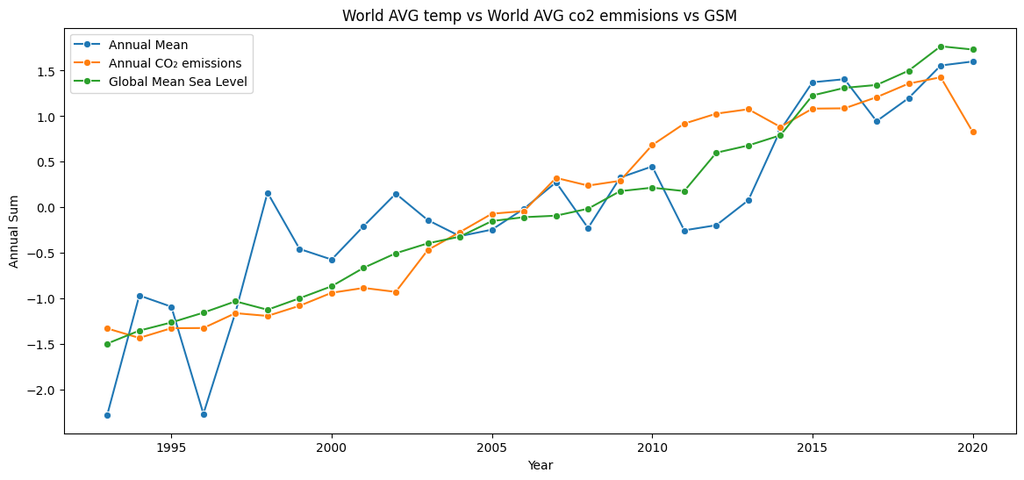

```python
import kagglehub
sealevel_data = pd.read_csv('/root/.cache/kagglehub/datasets/kkhandekar/global-sea-level-1993-2021/versions/2/sealevel.csv')

display(sealevel_data.head(3))

del sealevel_data['StdDevGMSL_noGIA']
del sealevel_data['SmoothedGSML_noGIA']
del sealevel_data['GMSL_GIA']
del sealevel_data['StdDevGMSL_GIA']
del sealevel_data['TotalWeightedObservations']
del sealevel_data['SmoothedGSML_GIA']
del sealevel_data['SmoothedGSML_GIA_sigremoved']

sealevel_data = sealevel_data.rename(columns={
    'GMSL_noGIA': 'Global Mean Sea Level',
    'Year': 'Year'
})
worldMerged = worldDF.merge(worldco2, on='Year')

finalDF = worldMerged.merge(sealevel_data, on='Year')

finalDF = finalDF.groupby('Year').agg({'Annual Mean': 'mean', '5-yr smooth': 'mean', 'Annual CO₂ emissions': 'sum', 'Global Mean Sea Level': 'sum'}).reset_index()
finalDF = finalDF[finalDF['Year'] < 2021]

display(finalDF.head(100))

finalDF = finalDF[finalDF['Year'] >= 1993]

#Normalize data (z-score)
finalDF['Annual Mean'] = (finalDF['Annual Mean'] - finalDF['Annual Mean'].mean()) / finalDF['Annual Mean'].std()
finalDF['Annual CO₂ emissions'] = (finalDF['Annual CO₂ emissions'] - finalDF['Annual CO₂ emissions'].mean()) / finalDF['Annual CO₂ emissions'].std()
finalDF['Global Mean Sea Level'] = (finalDF['Global Mean Sea Level'] - finalDF['Global Mean Sea Level'].mean()) / finalDF['Global Mean Sea Level'].std()

#plotting of graph
plt.figure(figsize=(14, 6))
sns.lineplot(data=finalDF, x='Year', y='Annual Mean', marker='o', label='Annual Mean')
sns.lineplot(data=finalDF, x='Year', y='Annual CO₂ emissions', marker='o', label='Annual CO₂ emissions')
sns.lineplot(data=finalDF, x='Year', y='Global Mean Sea Level', marker='o', label='Global Mean Sea Level')
plt.title(f'World AVG temp vs World AVG co2 emmisions vs GSM')
plt.ylabel('Annual Sum')
plt.xlabel('Year')
plt.legend()
```

Predicting Annual Mean Temperature Based on Sea Level and Historical Data:

Here we use a predictive model through linear regression to analyze the relationship between global mean sea levels and annual mean temperatures. It begins by merging the worldDF dataset with the sealevel_data, aggregating the annual mean temperature, smoothed temperature, and global mean sea level by year. It conducts exploratory data analysis (EDA) by visualizing annual mean temperatures and global mean sea levels over the years through line plots. A correlation matrix is computed to assess relationships between variables, which is displayed as a heatmap. Next, the code defines the features (5-year smoothed temperature and global mean sea level) and the target variable (annual mean temperature). It splits the dataset into training and testing sets using train_test_split. A linear regression model is trained on the training data. To predict the annual mean temperature for 2021, specific values for the smoothed temperature and global sea level are provided. The model’s prediction is printed alongside an evaluation of its performance using mean squared error (MSE) on the test set.

|  | Year | Annual Mean | 5-yr smooth | Annual CO₂ emissions |
| --- | --- | --- | --- | --- |
| 0 | 1901 | 18.705471 | 18.665824 | 1.489848e+08 |
| 1 | 1902 | 18.531000 | 18.614176 | 1.521439e+08 |
| 2 | 1903 | 18.580118 | 18.565118 | 1.630048e+08 |
| 3 | 1904 | 18.487647 | 18.523824 | 1.634754e+08 |
| 4 | 1905 | 18.555000 | 18.493471 | 1.681852e+08 |
| ... | ... | ... | ... | ... |
| 117 | 2018 | 19.851000 | 19.898941 | 9.524585e+08 |
| 118 | 2019 | 19.943353 | 19.902412 | 9.606857e+08 |
| 119 | 2020 | 19.954706 | 19.893412 | 9.142331e+08 |
| 120 | 2021 | 19.818059 | 19.877353 | 9.621958e+08 |
| 121 | 2022 | 19.868235 | 19.856471 | 9.674599e+08 |

122 rows × 4 columns

```
    Year  Annual Mean  5-yr smooth  Global Mean Sea Level
28  2021    19.818059    19.877353                 900.56
Year                       int64
Annual Mean              float64
5-yr smooth              float64
Global Mean Sea Level    float64
dtype: object
```

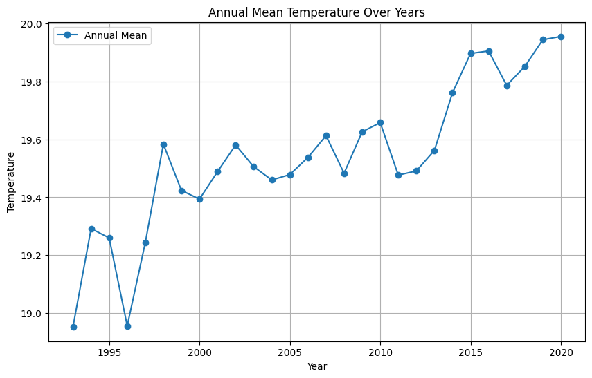

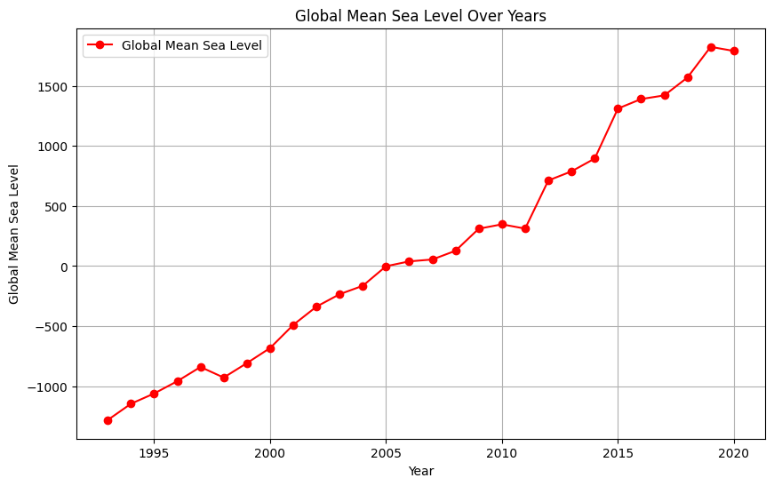

```
Correlation matrix:
                           Year  Annual Mean  5-yr smooth  \
Year                   1.000000     0.876042     0.954491
Annual Mean            0.876042     1.000000     0.907853
5-yr smooth            0.954491     0.907853     1.000000
Global Mean Sea Level  0.989610     0.878482     0.958030

                       Global Mean Sea Level
Year                                0.989610
Annual Mean                         0.878482
5-yr smooth                         0.958030
Global Mean Sea Level               1.000000
```

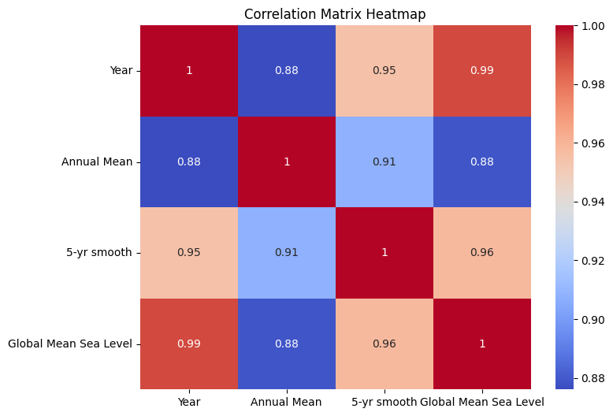

```
Predicted Annual Mean Temperature for 2021: 19.844129187036714

Mean Squared Error on test set: 0.010020260007875393
```

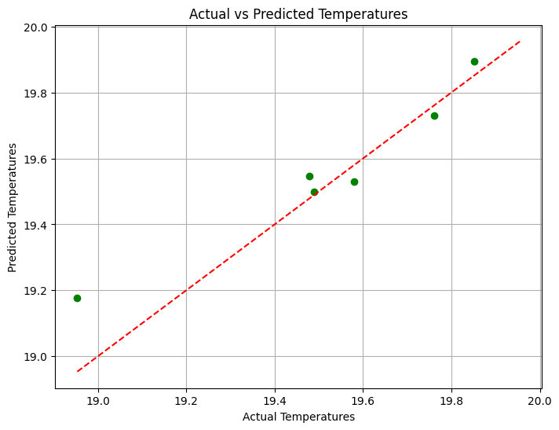

```python
from sklearn.model_selection import train_test_split
from sklearn.linear_model import LinearRegression
from sklearn.preprocessing import StandardScaler
from sklearn.metrics import mean_squared_error
import numpy as np


#load
finalDF = worldDF.merge(sealevel_data, on='Year')
finalDF = finalDF.groupby('Year').agg({'Annual Mean': 'mean', '5-yr smooth': 'mean', 'Global Mean Sea Level': 'sum'}).reset_index()

display(worldMerged)

moredata = finalDF[finalDF['Year'] > 2020].copy()
data = finalDF[finalDF['Year'] <= 2020].copy()

print(moredata.head())
print(data.dtypes)

#EDA
plt.figure(figsize=(10,6))
plt.plot(data['Year'], data['Annual Mean'], marker='o', label='Annual Mean')
plt.xlabel('Year')
plt.ylabel('Temperature')
plt.title('Annual Mean Temperature Over Years')
plt.legend()
plt.grid(True)
plt.show()

#Plot Annual Global sea
plt.figure(figsize=(10,6))
plt.plot(data['Year'], data['Global Mean Sea Level'], marker='o', color='red', label='Global Mean Sea Level')
plt.xlabel('Year')
plt.ylabel('Global Mean Sea Level')
plt.title('Global Mean Sea Level Over Years')
plt.legend()
plt.grid(True)
plt.show()

corr_matrix = data.corr()
print("\nCorrelation matrix:")
print(corr_matrix)

plt.figure(figsize=(8,6))
sns.heatmap(corr_matrix, annot=True, cmap='coolwarm')
plt.title('Correlation Matrix Heatmap')
plt.show()

X = data[['5-yr smooth', 'Global Mean Sea Level']]
y = data['Annual Mean']

#split
X_train, X_test, y_train, y_test = train_test_split(X, y, test_size=0.2, random_state=42)


#train the Model
model = LinearRegression()
model.fit(X_train, y_train)


X_2021 = pd.DataFrame({
    '5-yr smooth': [19.877353],
    'Global Mean Sea Level': [900.56]
})

temperature_2021 = model.predict(X_2021)
print(f"\nPredicted Annual Mean Temperature for 2021: {temperature_2021[0]}")

#Eval
y_pred = model.predict(X_test)

#calculate MSE
mse = mean_squared_error(y_test, y_pred)
print(f"\nMean Squared Error on test set: {mse}")

#Plot Actual vs Predicted Temperatures
plt.figure(figsize=(8,6))
plt.scatter(y_test, y_pred, color='green')
plt.plot([y.min(), y.max()], [y.min(), y.max()], 'r--')  # Line for perfect prediction
plt.xlabel('Actual Temperatures')
plt.ylabel('Predicted Temperatures')
plt.title('Actual vs Predicted Temperatures')
plt.grid(True)
plt.show()
```

**Modeling of Annual Mean Temperature Using Sea Level and CO₂ Emissions Data **

|  | Year | Annual Mean | 5-yr smooth | Annual CO₂ emissions | Global Mean Sea Level |
| --- | --- | --- | --- | --- | --- |
| 0 | 1993 | 18.953412 | 19.139118 | 6.337637e+08 | -1280.40 |
| 1 | 1994 | 19.291647 | 19.141176 | 6.214538e+08 | -1145.19 |
| 2 | 1995 | 19.259765 | 19.154412 | 6.341004e+08 | -1059.90 |
| 3 | 1996 | 18.956176 | 19.188176 | 6.519520e+08 | -957.47 |
| 4 | 1997 | 19.243412 | 19.244706 | 6.536962e+08 | -839.25 |
| 5 | 1998 | 19.583118 | 19.315235 | 6.500674e+08 | -927.24 |
| 6 | 1999 | 19.423412 | 19.389176 | 6.632737e+08 | -807.06 |
| 7 | 2000 | 19.393471 | 19.457824 | 6.802029e+08 | -681.74 |
| 8 | 2001 | 19.488353 | 19.511059 | 6.865069e+08 | -489.11 |
| 9 | 2002 | 19.580235 | 19.542118 | 7.003022e+08 | -337.42 |
| 10 | 2003 | 19.505235 | 19.553706 | 7.358891e+08 | -233.77 |
| 11 | 2004 | 19.459706 | 19.552588 | 7.591680e+08 | -163.73 |
| 12 | 2005 | 19.478235 | 19.542412 | 7.830928e+08 | -1.14 |
| 13 | 2006 | 19.537412 | 19.529647 | 8.084110e+08 | 39.30 |
| 14 | 2007 | 19.612412 | 19.519059 | 8.297299e+08 | 55.05 |
| 15 | 2008 | 19.482765 | 19.514176 | 8.424912e+08 | 127.77 |
| 16 | 2009 | 19.625765 | 19.518176 | 8.259296e+08 | 311.22 |
| 17 | 2010 | 19.657353 | 19.532588 | 8.723997e+08 | 347.48 |
| 18 | 2011 | 19.476176 | 19.560647 | 9.003623e+08 | 311.90 |
| 19 | 2012 | 19.490824 | 19.604882 | 9.133340e+08 | 712.46 |
| 20 | 2013 | 19.561529 | 19.662176 | 9.190823e+08 | 788.25 |
| 21 | 2014 | 19.760412 | 19.725471 | 9.209330e+08 | 894.63 |
| 22 | 2015 | 19.895882 | 19.787353 | 9.198844e+08 | 1310.59 |
| 23 | 2016 | 19.904588 | 19.841059 | 9.202508e+08 | 1389.71 |
| 24 | 2017 | 19.785647 | 19.879765 | 9.347429e+08 | 1420.10 |
| 25 | 2018 | 19.851000 | 19.898941 | 9.524585e+08 | 1568.99 |
| 26 | 2019 | 19.943353 | 19.902412 | 9.606857e+08 | 1824.07 |
| 27 | 2020 | 19.954706 | 19.893412 | 9.142331e+08 | 1789.84 |
| 28 | 2021 | 19.818059 | 19.877353 | 9.621958e+08 | 900.56 |

```
    Year  Annual Mean  5-yr smooth  Annual CO₂ emissions  \
28  2021    19.818059    19.877353          9.621958e+08

    Global Mean Sea Level
28                 900.56
Year                       int64
Annual Mean              float64
5-yr smooth              float64
Annual CO₂ emissions     float64
Global Mean Sea Level    float64
dtype: object

Correlation matrix:
                           Year  Annual Mean  5-yr smooth  \
Year                   1.000000     0.876042     0.954491
Annual Mean            0.876042     1.000000     0.907853
5-yr smooth            0.954491     0.907853     1.000000
Annual CO₂ emissions   0.976563     0.794283     0.894109
Global Mean Sea Level  0.989610     0.878482     0.958030

                       Annual CO₂ emissions  Global Mean Sea Level
Year                               0.976563               0.989610
Annual Mean                        0.794283               0.878482
5-yr smooth                        0.894109               0.958030
Annual CO₂ emissions               1.000000               0.953670
Global Mean Sea Level              0.953670               1.000000
```

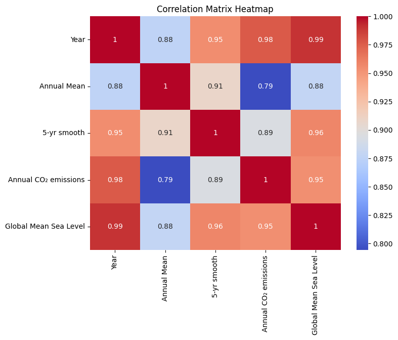

```
Predicted Annual Mean Temperature for 2021: 19.778108900614267

Mean Squared Error on test set: 0.010330506620598324
```

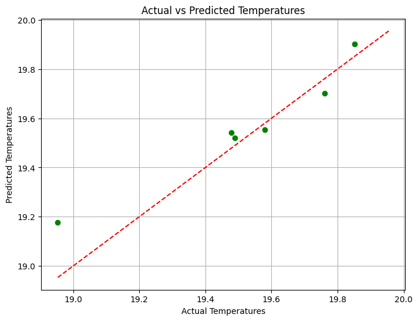

```python
from sklearn.model_selection import train_test_split
from sklearn.linear_model import LinearRegression
from sklearn.preprocessing import StandardScaler
from sklearn.metrics import mean_squared_error
import numpy as np

sealevel_data = pd.read_csv('/root/.cache/kagglehub/datasets/kkhandekar/global-sea-level-1993-2021/versions/2/sealevel.csv')
worldMerged = worldDF.merge(worldco2, on='Year')

del sealevel_data['StdDevGMSL_noGIA']
del sealevel_data['SmoothedGSML_noGIA']
del sealevel_data['GMSL_GIA']
del sealevel_data['StdDevGMSL_GIA']
del sealevel_data['TotalWeightedObservations']
del sealevel_data['SmoothedGSML_GIA']
del sealevel_data['SmoothedGSML_GIA_sigremoved']

sealevel_data = sealevel_data.rename(columns={
    'GMSL_noGIA': 'Global Mean Sea Level',
    'Year': 'Year'
})

finalDF = worldMerged.merge(sealevel_data, on='Year')

finalDF = finalDF.groupby('Year').agg({'Annual Mean': 'mean', '5-yr smooth': 'mean', 'Annual CO₂ emissions': 'mean', 'Global Mean Sea Level': 'sum'}).reset_index()
display(finalDF)

moredata = finalDF[finalDF['Year'] > 2020].copy()
data = finalDF[finalDF['Year'] <= 2020].copy()

print(moredata.head())
print(data.dtypes)

corr_matrix = data.corr()
print("\nCorrelation matrix:")
print(corr_matrix)

plt.figure(figsize=(8,6))
sns.heatmap(corr_matrix, annot=True, cmap='coolwarm')
plt.title('Correlation Matrix Heatmap')
plt.show()

X = data[['5-yr smooth', 'Global Mean Sea Level', 'Annual CO₂ emissions']]
y = data['Annual Mean']

X_train, X_test, y_train, y_test = train_test_split(X, y, test_size=0.2, random_state=42)

model = LinearRegression()
model.fit(X_train, y_train)

X_2021 = pd.DataFrame({
    '5-yr smooth': [19.877353],
    'Global Mean Sea Level': [900.56],
    'Annual CO₂ emissions': [9.621958e+08]

})

temperature_2021 = model.predict(X_2021)
print(f"\nPredicted Annual Mean Temperature for 2021: {temperature_2021[0]}")

y_pred = model.predict(X_test)

mse = mean_squared_error(y_test, y_pred)
print(f"\nMean Squared Error on test set: {mse}")

plt.figure(figsize=(8,6))
plt.scatter(y_test, y_pred, color='green')
plt.plot([y.min(), y.max()], [y.min(), y.max()], 'r--')
plt.xlabel('Actual Temperatures')
plt.ylabel('Predicted Temperatures')
plt.title('Actual vs Predicted Temperatures')
plt.grid(True)
plt.show()
```

**Conclusion**

From the initial analysis, it is evident that the focus on climate change is crucial, particularly in light of the alarming trends observed in global temperatures. The dataset reveals a consistent increase in average annual temperatures, underscoring the urgency of addressing climate-related issues. This trend is particularly concerning as it correlates with rising sea levels, which pose significant threats to coastal communities and ecosystems. Moreover, the project delves into the implications of carbon emissions on temperature fluctuations. The data indicates a strong correlation between increased CO₂ emissions and rising temperature. This relationship highlights the importance of integrating climate science into public policy discussions to mitigate the impacts of climate change. The predictive modeling aspect of the project further enhances our understanding of future climate scenarios. Although the model may not have predicted the exact temperatue, this was expected as the model is fairly limited. To fully understand how to predict temperature, one must include many more features like solar radiation, gravitation and more.

By employing linear regression techniques, we can estimate future temperature changes based on historical patterns. This predictive capability is crucial for informing stakeholders and guiding decision-making processes related to climate adaptation and mitigation strategies. In conclusion, this project not only sheds light on the pressing challenges posed by climate change but also emphasizes the necessity for continued research and proactive measures.